# GPS Visualization Markdown

2024-11-19

## Familiarization and Cleaning

1. Load appropriate packages and libraries
2. Import CMJ data
3. Write data into an Excel file for export
4. Familiarize myself data structure, formatting, ranges, etc in Excel through exploratory sorting/filtering
5. Sort by date as output will be chronological
6. Remove outliers based on first and last dates of training and extreme total distance values

## Data Analysis

1. Correlation of Total Distance and High Speed Distance for whole data set, as well as average weekly correlation per player

```
# Overall correlation
overall_cor <- gps_data_clean %>%
  filter(`Total Distance` > 0) %>%
  summarise(
    correlation = cor(`Total Distance`, `Distance > 85%`,
                      method = "pearson", use = "complete.obs"),
    n_observations = n()
  ) %>%
  mutate(type = "Overall Dataset")

# Average weekly correlation per athlete
player_avg_cors <- gps_data_clean %>%
  mutate(Week = floor_date(Date, "week")) %>%
  group_by(player_id, Week) %>%
  filter(n() >= 3) %>%
  summarise(
    sd_total = sd(`Total Distance`, na.rm = TRUE),
    sd_hsd = sd(`Distance > 85%`, na.rm = TRUE),
    correlation = if(sd_total > 0 && sd_hsd > 0) {
      cor(`Total Distance`, `Distance > 85%`,
          method = "pearson", use = "complete.obs")
    } else {
      NA_real_
    },
    n_observations = n(),
    .groups = "drop"
  ) %>%
  filter(!is.na(correlation)) %>%
  group_by(player_id) %>%
  summarise(
    avg_correlation = mean(correlation, na.rm = TRUE),
    total_weeks = n(),
    total_observations = sum(n_observations)
  ) %>%
  arrange(player_id)
```

2. Calculate Acute Load, Chronic Load, and ACWR for both High Speed Distance and Total Distance

```
# Begin ACWR
gps_data_clean <- gps_data_clean %>%
  # Group by player so calculations are player-specific
  group_by(player_id) %>%
  arrange(Date) %>%
  mutate(
    # High Speed Distance calculations
    Ac_HSD = round(rollmean(`Distance > 85%`, k = 7, fill = NA, align = "right"), 1),
    Ch_HSD = round(rollmean(`Distance > 85%`, k = 28, fill = NA, align = "right"), 1),
    ACWR_HSD = round(Ac_HSD / Ch_HSD, 2),

    # Total Distance calculations
    Ac_tdist = round(rollmean(`Total Distance`, k = 7, fill = NA, align = "right"), 1),
    Ch_tdist = round(rollmean(`Total Distance`, k = 28, fill = NA, align = "right"), 1),
    ACWR_tdist = round(Ac_tdist / Ch_tdist, 2)
  ) %>%
  ungroup()
```

3. Visually double-check ACWR calculations for execution and accuracy

```
# Double check the results for one random player
example_player <- gps_data_clean %>%
  filter(player_id == 69756) %>%
  select(Date, `Distance > 85%`, Ac_HSD, Ch_HSD, ACWR_HSD,
         `Total Distance`, Ac_tdist, Ch_tdist, ACWR_tdist)
```

4. Find date range of Player 69756’s data and filter out all dates before and after (for conciseness of plot)

```
# Get the exact first and last dates with Total Distance data for Player 69756
player_dates <- gps_data_clean %>%
  filter(player_id == 69756) %>%
  filter(!is.na(`Total Distance`)) %>%
  summarise(
    start_date = min(Date[`Total Distance` > 0]),
    end_date = max(Date[`Total Distance` > 0])
  )

# Get data within Player 69756's date range
player_data <- gps_data_clean %>%
  filter(player_id == 69756) %>%
  filter(Date >= player_dates$start_date & Date <= player_dates$end_date)
```

5. Calculate weekly averages and sums of distance metrics to be used in plot

```
# Calculate weekly averages and exposures for Player 69756
weekly_distances <- player_data %>%
  mutate(Week = floor_date(Date, "week")) %>%
  group_by(Week) %>%
  summarise(
    `Total Distance` = mean(`Total Distance`, na.rm = TRUE),
    `High Speed Distance` = sum(`Distance > 85%`, na.rm = TRUE),
    `High Speed Exposures` = sum(`Distance > 85%` > 50, na.rm = TRUE)
  )
```

## Plot Creation

1. Plot creation for distance metrics correlation

```
# Create correlation plot with r value from overall_cor
correlation_plot <- ggplot(gps_data_clean %>% filter(`Total Distance` > 0),
                           aes(x = `Total Distance`, y = `Distance > 85%`)) +
  geom_point(alpha = 0.3, color = "blue") +
  geom_smooth(method = "lm", color = "red", se = FALSE) +
  labs(
    title = "Total Distance vs High Speed Distance",
    x = "Total Distance (m)",
    y = "High Speed Distance (m)"
  ) +
  annotate(
    "text",
    x = max(gps_data_clean$`Total Distance`, na.rm = TRUE) * 0.8,
    y = max(gps_data_clean$`Distance > 85%`, na.rm = TRUE) * 0.9,
    label = paste("r =", round(overall_cor$correlation, 2)),
    size = 5,
    fontface = "bold"
  ) +
  theme_minimal() +
  theme(
    plot.title = element_text(size = 16, face = "bold", hjust = 0.5),
    axis.title = element_text(size = 12, face = "bold"),
    axis.text = element_text(size = 10),
    plot.background = element_rect(fill = "white", color = NA),
    panel.background = element_rect(fill = "white", color = NA)
  )

# Save plot
ggsave("distance_correlation.png", correlation_plot, width = 10, height = 8, units = "in", dpi = 300, bg = "white")
```

2. Plot creation for distance metrics trends

```
# Create the plot with dual y-axes with formatting
player_plot <- ggplot() +
  geom_bar(data = weekly_distances, aes(x = Week, y = `Total Distance`, fill = "Weekly Avg Total Dist"),
           stat = "identity", alpha = 0.5, width = 6) +
  geom_bar(data = weekly_distances, aes(x = Week, y = `High Speed Distance`, fill = "Weekly Total HSD"),
           stat = "identity", alpha = 0.7, width = 6) +
  geom_smooth(data = player_data,
              aes(x = Date, y = ACWR_HSD * max(weekly_distances$`Total Distance`, na.rm = TRUE) / max(player_data$ACWR_HSD, na.rm = TRUE),
                  color = "ACWR HSD"), linewidth = 1, se = FALSE, span = 0.2) +
  geom_smooth(data = player_data,
              aes(x = Date, y = ACWR_tdist * max(weekly_distances$`Total Distance`, na.rm = TRUE) / max(player_data$ACWR_tdist, na.rm = TRUE),
                  color = "ACWR Total Dist"), linewidth = 1, se = FALSE, span = 0.2) +
  geom_hline(yintercept = c(0.8, 1.3) * max(weekly_distances$`Total Distance`, na.rm = TRUE) / max(player_data$ACWR_HSD, na.rm = TRUE),
             linetype = "dashed", color = "purple", linewidth = 0.8) +
  scale_y_continuous(name = "Total Distance",
                     sec.axis = sec_axis(~. * max(player_data$ACWR_HSD, na.rm = TRUE) / max(weekly_distances$`Total Distance`, na.rm = TRUE),
                                         name = "ACWR Ratio", breaks = seq(0, 2, by = 0.2))) +
  scale_x_date(limits = c(player_dates$start_date, player_dates$end_date), expand = c(0, 0),
               breaks = seq(from = player_dates$start_date, to = player_dates$end_date, by = "1 month"),
               labels = scales::date_format("%b %Y")) +
  scale_fill_manual(values = c("Weekly Avg Total Dist" = "blue", "Weekly Total HSD" = "red")) +
  scale_color_manual(values = c("ACWR HSD" = "orange", "ACWR Total Dist" = "black")) +
  theme_minimal() +
  labs(title = "Player 69756 Total Distance and HSD Metrics", x = "Date", fill = "Bars", color = "Lines") +
  theme(
    plot.title = element_text(size = 24, face = "bold", hjust = 0.5, margin = margin(b = 20)),
    axis.title = element_text(size = 16, face = "bold"),
    axis.text = element_text(size = 12, face = "bold", color = "black"),
    axis.text.x = element_text(angle = 45, hjust = 1),
    legend.title = element_text(size = 14, face = "bold"),
    legend.text = element_text(size = 12, face = "bold"),
    legend.position = "bottom",
    legend.box = "horizontal",
    legend.margin = margin(t = 10)
  )
```

## Visualizations

1. Correlation of Total Distance vs High Speed Distance

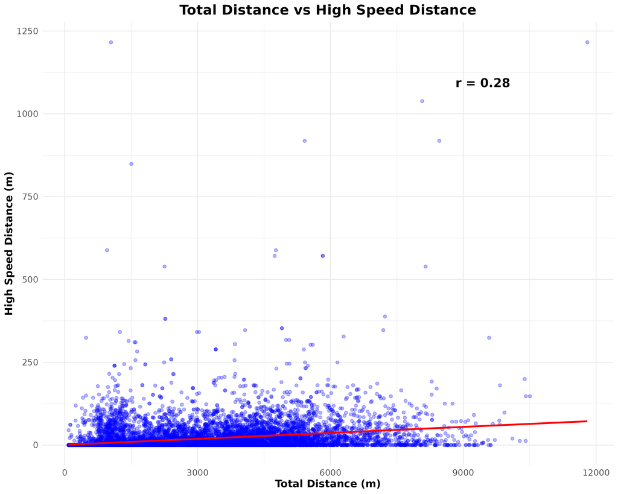

   Correlation of Total Distance vs High Speed Distance

2. Player 69756 HSD Trends: HSD and Total Distance Averages, Totals, and ACWRs

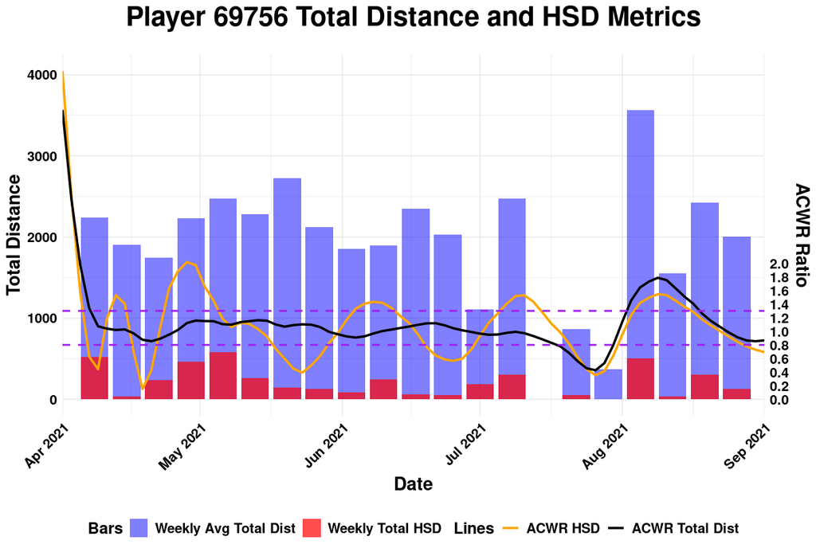

   Player 69756 HSD Trends

## Key Considerations

– **Logic and Thought Process**

- For potential outliers, Total Distance was selected as that value will be > 0 on any training day, as opposed to High Speed Distance
- With Excel’s ease of use for data viewing and sorting, I noticed the upper end of Total Distance was around 11000 with multiple entries at +5 million. For the lower end, the lowest Total Distance value that also had any High Speed Distance was ~87
  - Outlier threshold (>12000 and <85) was selected by visual inspection because of the “unbounded” nature of the measurement and the significance of 0 values, instead of using a method like standard deviation
- Although I removed Total Distance 0 values before and after the first and last dates with data, I left 0 values as off-days for the ACWR
- Visual guidelines of ACWR at 1.3 and 0.8 (the “sweet spot”) for easier interpretation of risk for under- or over-training. Although the narrative about ACWR has changed over the years, I still believe in the premise
- High Speed Distance needs some context so that’s why Total Distance weekly and ACWR numbers were included for comparison

– **Findings and Practical Applications**

- It’s not fair to assume High Speed Distance goes up when Total Distance goes up. With a correlation of 0.28 for the whole data set, and average individual player weekly correlations with at least 10 weeks of data ranges from 0.33 to 0.75, this is a poor relationship
- The Total Distance ACWR remained pretty stable throughout the season, besides the few weeks following what I’m assuming might be an All-Star Break
- The High Speed Distance ACWR had significantly more weekly fluctuations, bouncing back and forth between under- and over-training every ~3 weeks
- I would recommend developing a weekly minimum threshold of High Speed Distance to qualify as sufficient (speed training residual is 5 +/- 3 days) to keep ACWR above 0.8

– **Limitations and Future Considerations**

- Evaluating entire data set together, no consideration of position nor session type
  - Dive in distance standards/norms per position group per session type
- Evaluate if +85% if achieved during running out a single or double (position players) or what distance of sprint is needed (pitchers) for more practical programming
- Develop an optimal “weekly HSD exposures” (ie days > 50), assuming it’ll be ~1-3 days to try to maintain a high-low High Speed Distance training schedule, if possible